# Modeling and prediction for movies

## Setup

### Load packages and data

```r
library(ggplot2)
library(dplyr)
library(statsr)
library(knitr)
library(scales)
library(formattable)
library(psych)#improved pairs plot

### Load data
load("movies.Rdata")
```

## Part 1: Data

The goal of this section is:

*Describe how the observations in the sample are collected and the implications of this data collection method on the scope of inference (generalizability / causality).*

### Introduction to the Data

The data set “movies” is comprised of 651 **randomly sampled movies** produced and released before 2016. The movies are from American Studios. (We know this because the MPAA Ratings in the data applies only to American movies.) This data set includes information from both Rotten Tomatoes and IMDb.

#### About Rotten Tomatoes

[Rotten Tomatoes](https://www.rottentomatoes.com/about/) and the Tomatometer™ rating is the most trusted measurement of quality entertainment. As the leading **online aggregator** of movie and TV show reviews from professional critics, Rotten Tomatoes offers the most comprehensive guide to what’s fresh. The world famous Tomatometer™ rating represents the percentage of positive professional reviews for films and TV shows and is used by millions every day, to help with their entertainment viewing decisions. Rotten Tomatoes designates the best reviewed movies and TV shows as Certified Fresh. That accolade is awarded with Tomatometer ratings of 75% and higher and a required minimum number of reviews.

#### About IMDB

The [Internet Movie Database](https://en.wikipedia.org/wiki/IMDb) is an online database of information related to films, television programs and video games, including cast, production crew, fictional characters, biographies, plot summaries, trivia and reviews. As of June 2016, IMDb has approximately 3.7 million titles (including episodes) and 7 million personalities in its database.

The site enables **registered users to submit new material and request edits** to existing entries. Although all data is checked before going live, the system has been open to abuse and occasional errors are acknowledged. **Users are also invited to rate** any film on a scale of 1 to 10, and the totals are converted into a weighted mean-rating that is displayed beside each title, with online filters employed to deter ballot-stuffing. The site also features message boards which stimulate regular debates among authenticated users.

### Scope of Inference

In *Introduction to the Data* above, a few phrases have been **highlighted**. These phrases provide key information about the generalizability of the data. This information suggests the data set should be considered the result of an observational retrospective study that uses a random sampling design to select a representative sample from U.S. movies. When random sampling has been employed in data collection, the results should be generalizable to the target population. Therefore, the results of the analysis should be generalizable to all the movies released between 1970 - 2014.

Note that observational studies show associations. In a data analysis, association does not imply causation. Causation can only be inferred from a randomized experiment. This analysis does not meet the requirements of an experiment.

While we has assumed the data to be a random sample, there are always potential sources of bias that can skew results.

#### Sources of Bias

- The study may suffer from “voluntary response bias” since people with strong responses participate. The voluntary participants may not be representative of the US population. Also note that professional critics provide guidance for Rotten Tomatoes and authenticated users provide IMDB data.
- Non-Response Bias: Simple random sampling means that each case in the population has an equal chance of being included and there is no implied connection between the cases in the sample. However, even when people are picked at random, caution must be exercised if the non-response is high. If only 30% of the people randomly sampled for a survey respond, then it is uncertain whether the results are representative of the entire population. This non-response bias can skew results. Because we do not know how many professional critics or authenticated users provide feedback on only certain movies, non-response bias may exist.

Even with these types of bias, this analysis assumes the data to be randomly sampled.

## Part 2: Research question

The project objective for this section:

*Develop a research question that you want to answer using these data and a multiple linear regression model. You should phrase your research question in a way that matches up with the scope of inference your dataset allows for. Include a brief discussion why this question is of interest to you and/or your audience.*

I have a teenage daughter who sees movies with her friends every week. Occasionally I take a gaggle of girls to the movies and see it with them - sitting in a different part of the theater of course! Some of the movies are just terrible - in my opinion. I am often amazed how frequently my perceptions differ from young teenagers. (I know I should not be surprised.) Do the variables that contribute to movie popularity more closely match my views or the perceptions of a teenage?

Therefore my research question is:

**What does it take to make a movie popular?**

## Part 3: Exploratory data analysis

The project objective for this section:

*Perform exploratory data analysis (EDA) that addresses the research question. The EDA should contain numerical summaries and visualizations. Each R output and plot should be accompanied by a brief interpretation.*

### Data details

Before any data analysis, understanding the data is critical. Lets first look at the 32 variables available to us:

The data frame has 651 records and 32 attributes:

- `title`: Title of movie
- `title_type`: Type of movie (Documentary, Feature Film, TV Movie)
- `genre`: Genre of movie (Action & Adventure, Comedy, Documentary, Drama, Horror, Mystery & Suspense, Other)
- `runtime`: Runtime of movie (in minutes)
- `mpaa_rating`: MPAA rating of the movie (G, PG, PG-13, R, Unrated)
- `studio`: Studio that produced the movie
- `thtr_rel_year`: Year the movie is released
- `thtr_rel_month`: Month the movie is released
- `thtr_rel_day`: Day of month the movie is released
- `dvd_rel_year`: Year the DVD is released
- `dvd_rel_month`: Month the DVD is released
- `dvd_rel_day`: Day of month the DVD is released
- `imdb_rating`: The IMDB rating
- `imdb_num_votes`: Number of votes on IMDB
- `critics_rating`: Categorical variable for critics rating on Rotten Tomatoes (Certified Fresh, Fresh, Rotten)
- `critics_score`: Critics score on Rotten Tomatoes
- `audience_rating`: Categorical variable for audience rating on Rotten Tomatoes (Spilled, Upright)
- `audience_score`: Audience score on Rotten Tomatoes
- `best_pic_nom`: Whether or not the movie was nominated for a best picture Oscar (no, yes)
- `best_pic_win`: Whether or not the movie won a best picture Oscar (no, yes)
- `best_actor_win`: Whether or not one of the main actors in the movie ever won an Oscar (no, yes) – note that this is not necessarily whether the actor won an Oscar for their role in the given movie
- `best_actress win`: Whether or not one of the main actresses in the movie ever won an Oscar (no, yes) – not that this is not necessarily whether the actresses won an Oscar for their role in the given movie
- `best_dir_win`: Whether or not the director of the movie ever won an Oscar (no, yes) – not that this is not necessarily whether the director won an Oscar for the given movie
- `top200_box`: Whether or not the movie is in the Top 200 Box Office list on BoxOfficeMojo (no, yes)
- `director`: Director of the movie
- `actor1-actor5`: List of first 5 main actors in the movie (abridged cast), this information was used to determine whether the movie casts an actor or actress who won a best actor or actress Oscar
- `imdb_url`: Link to IMDB page for the movie
- `imdb_id`: IMDB ID of the movie
- `rt_url`: Link to Rotten Tomatoes page for the movie

#### Response Variable Selection

The `audience_score` is the response variable for my analysis. It is the variable we will solve for in the analysis. Why did I chose `audience_score` instead of the `imdb_rating`? No specific reason. It was a coin toss. Both variables are correlated so picking one over the other is a random choice on my part. Here is the correlation calculation:

```r
cor(movies$imdb_rating, movies$audience_score)
```

```
## [1] 0.8648652
```

#### Filter the Data

Not all of the variables are relevant to my research question. I have limited the movies data set to movies released later than 1999. Younger people likely hold a certain level of prejudice against *old movies*. I also remove the dates related to release schedules and all the individual actors.

```r
movies_filtered <- filter(movies, thtr_rel_year >1999)
movies_filtered <- select(movies_filtered, c(-(thtr_rel_year:dvd_rel_day), -(actor1:rt_url)))
```

```r
removeGenres <- c("Art House & International", "Musical & Performing Arts", "Science Fiction & Fantasy")
movies_filtered <- filter(movies_filtered, genre != removeGenres)
movies_filtered <- filter(movies_filtered, title_type == "Feature Film")
movieRating <- c("G", "PG", "PG-13")
movies_filtered <- filter(movies_filtered, mpaa_rating %in% movieRating)
movies_filtered <- na.omit(movies_filtered)
```

There are still some variables that I do not need for my analysis. For example, I have assumed the name of the movie is not relevant. Similarly, I do not need the `title_type` since I have already selected *Feature Film*. The variable `critics_rating` is simply a categorical representation of `critics_score`, it too is removed from the data set. Similarly, `audience_rating` is a categorical representation of `audience_score` so it is removed. Lastly, I have asked my daughter and her friends if the studio that makes a movie makes any difference to them. The answer was a resounding *No*. I received the same response when I asked about the director of a movie.

```r
movies_filtered <- select(movies_filtered, c(-(title:title_type), -critics_rating, -audience_rating, -studio, -director))
```

Let’s see what our reduced data looks like:

```r
dim(movies_filtered)
```

```
## [1] 117  13
```

```r
str(movies_filtered)
```

```
## Classes 'tbl_df' and 'data.frame':   117 obs. of  13 variables:
##  $ genre           : Factor w/ 11 levels "Action & Adventure",..: 6 4 6 2 1 6 6 9 9 2 ...
##  $ runtime         : num  101 100 90 87 108 135 123 119 115 87 ...
##  $ mpaa_rating     : Factor w/ 6 levels "G","NC-17","PG",..: 4 4 4 3 3 4 4 4 4 1 ...
##  $ imdb_rating     : num  7.3 5.9 3.6 7 6.5 6.7 7.7 6.5 6.6 4.4 ...
##  $ imdb_num_votes  : int  12285 25808 21268 56128 290356 5258 225130 62241 110238 21501 ...
##  $ critics_score   : num  96 25 29 68 52 50 27 52 43 12 ...
##  $ audience_score  : num  81 53 19 77 55 49 75 56 58 52 ...
##  $ best_pic_nom    : Factor w/ 2 levels "no","yes": 1 1 1 1 1 1 1 1 1 1 ...
##  $ best_pic_win    : Factor w/ 2 levels "no","yes": 1 1 1 1 1 1 1 1 1 1 ...
##  $ best_actor_win  : Factor w/ 2 levels "no","yes": 1 1 1 1 1 1 1 1 2 1 ...
##  $ best_actress_win: Factor w/ 2 levels "no","yes": 1 1 1 1 1 1 1 1 1 1 ...
##  $ best_dir_win    : Factor w/ 2 levels "no","yes": 1 1 1 1 1 1 1 1 1 1 ...
##  $ top200_box      : Factor w/ 2 levels "no","yes": 1 1 1 1 1 1 1 1 1 1 ...
```

```r
summary(movies_filtered)
```

```
##                        genre       runtime     mpaa_rating  imdb_rating
##  Drama                    :51   Min.   : 68   G      : 4   Min.   :1.900
##  Comedy                   :26   1st Qu.: 91   NC-17  : 0   1st Qu.:5.300
##  Action & Adventure       :22   Median :101   PG     :32   Median :6.300
##  Mystery & Suspense       : 9   Mean   :105   PG-13  :81   Mean   :6.005
##  Animation                : 7   3rd Qu.:119   R      : 0   3rd Qu.:6.700
##  Musical & Performing Arts: 1   Max.   :152   Unrated: 0   Max.   :8.500
##  (Other)                  : 1
##  imdb_num_votes   critics_score   audience_score best_pic_nom best_pic_win
##  Min.   :  2271   Min.   : 1.00   Min.   :11.0   no :114      no :117
##  1st Qu.: 16955   1st Qu.:19.00   1st Qu.:40.0   yes:  3      yes:  0
##  Median : 48137   Median :42.00   Median :54.0
##  Mean   : 80919   Mean   :43.09   Mean   :54.5
##  3rd Qu.: 88777   3rd Qu.:60.00   3rd Qu.:70.0
##  Max.   :797101   Max.   :96.00   Max.   :92.0
##
##  best_actor_win best_actress_win best_dir_win top200_box
##  no :96         no :104          no :112      no :114
##  yes:21         yes: 13          yes:  5      yes:  3
##
##
##
##
##
```

Take note of the distribution of the last four variables. The number of `Yes` responses to `No` responses is unbalanced. To attenuate the potential impact of this unbalanced data, I will combine several variables into one. Specifically, if any of the following factor variables is *Yes*, then a new variable called `besy_any` will be *Yes*. This consolidates the six variables into one.

- `best_pic_nom`
- `best_pic_win`
- `best_actor_win`
- `best_actress win`
- `best_dir_win`
- `top200_box`

```r
#Create a new varaible where best_anything = Yes if any best* = Yes
movies_filtered <- mutate(movies_filtered, best_any=ifelse(best_pic_nom=="yes", 1,
               ifelse(best_pic_win=="yes", 1,
               ifelse(best_actor_win=="yes", 1,
               ifelse(best_actress_win=="yes", 1,
               ifelse(best_dir_win=="yes", 1,
               ifelse(top200_box=="yes", 1, 0)))))))
#Make best_any into a factor
movies_filtered$best_any <- factor(movies_filtered$best_any, labels = c("No", "Yes"))
#Remove the 6 variables that have been consolidated into best_any
movies_filtered <- select(movies_filtered, genre, runtime, mpaa_rating, imdb_rating, imdb_num_votes, critics_score, audience_score, best_any)
```

#### Final Working Data Set

We have made many data transformations. Let’s review the current state of the data:

```r
dim(movies_filtered)
```

```
## [1] 117   8
```

```r
str(movies_filtered)
```

```
## Classes 'tbl_df', 'tbl' and 'data.frame':    117 obs. of  8 variables:
##  $ genre         : Factor w/ 11 levels "Action & Adventure",..: 6 4 6 2 1 6 6 9 9 2 ...
##  $ runtime       : num  101 100 90 87 108 135 123 119 115 87 ...
##  $ mpaa_rating   : Factor w/ 6 levels "G","NC-17","PG",..: 4 4 4 3 3 4 4 4 4 1 ...
##  $ imdb_rating   : num  7.3 5.9 3.6 7 6.5 6.7 7.7 6.5 6.6 4.4 ...
##  $ imdb_num_votes: int  12285 25808 21268 56128 290356 5258 225130 62241 110238 21501 ...
##  $ critics_score : num  96 25 29 68 52 50 27 52 43 12 ...
##  $ audience_score: num  81 53 19 77 55 49 75 56 58 52 ...
##  $ best_any      : Factor w/ 2 levels "No","Yes": 1 1 1 1 1 1 1 1 2 1 ...
```

```r
summary(movies_filtered)
```

```
##                        genre       runtime     mpaa_rating  imdb_rating
##  Drama                    :51   Min.   : 68   G      : 4   Min.   :1.900
##  Comedy                   :26   1st Qu.: 91   NC-17  : 0   1st Qu.:5.300
##  Action & Adventure       :22   Median :101   PG     :32   Median :6.300
##  Mystery & Suspense       : 9   Mean   :105   PG-13  :81   Mean   :6.005
##  Animation                : 7   3rd Qu.:119   R      : 0   3rd Qu.:6.700
##  Musical & Performing Arts: 1   Max.   :152   Unrated: 0   Max.   :8.500
##  (Other)                  : 1
##  imdb_num_votes   critics_score   audience_score best_any
##  Min.   :  2271   Min.   : 1.00   Min.   :11.0   No :81
##  1st Qu.: 16955   1st Qu.:19.00   1st Qu.:40.0   Yes:36
##  Median : 48137   Median :42.00   Median :54.0
##  Mean   : 80919   Mean   :43.09   Mean   :54.5
##  3rd Qu.: 88777   3rd Qu.:60.00   3rd Qu.:70.0
##  Max.   :797101   Max.   :96.00   Max.   :92.0
##
```

Things are looking OK to proceed. We have kept the data of interest and consolidated unbalance data into a single variable. Before moving on, let’s see if `best_any` is more balanced than the other six variables we used to have:

```r
table(movies_filtered$best_any)
```

```
##
##  No Yes
##  81  36
```

This looks much better!

#### Data Exploration & Discovery

Let’s focus a moment of `audience_score`. Since it is the variable of interest, let’s consider it’s distribution. For linear regression, we need the date to be normally distributed.

```r
summary(movies_filtered$audience_score)
```

```
##    Min. 1st Qu.  Median    Mean 3rd Qu.    Max.
##    11.0    40.0    54.0    54.5    70.0    92.0
```

The mean and median are very close suggesting the data may indeed be normal. Let’s confirm this will a histogram:

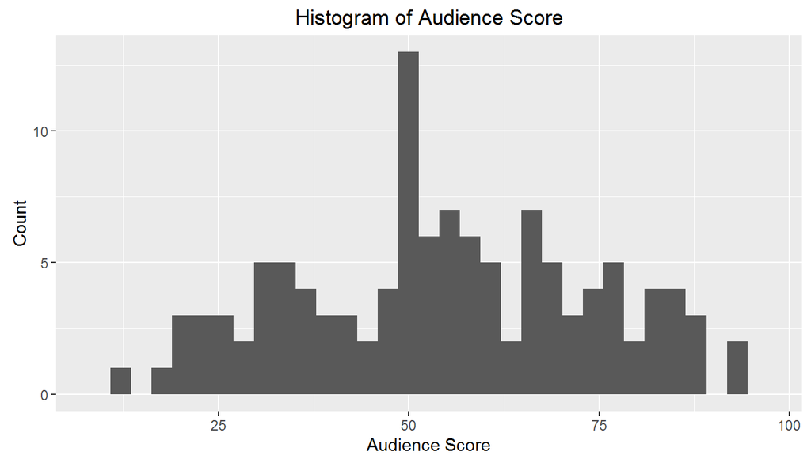

```r
ggplot(movies_filtered, aes(x = audience_score)) + geom_histogram() + xlab("Audience Score") + ylab("Count") + ggtitle("Histogram of Audience Score")
```

The histogram appears relatively normal.

Our new data set contains the variables to be used in our model. It is now easy for us to plot them using the plot function. Because the base R pairs plot does not display very useful information when many categorical factors are in the data set, I opted to use a modified pairs plot available in the psyche package. (Psyche functions are primarily for multivariate analysis and scale construction using factor analysis, principal component analysis, cluster analysis and reliability analysis, although others provide basic descriptive statistics.)

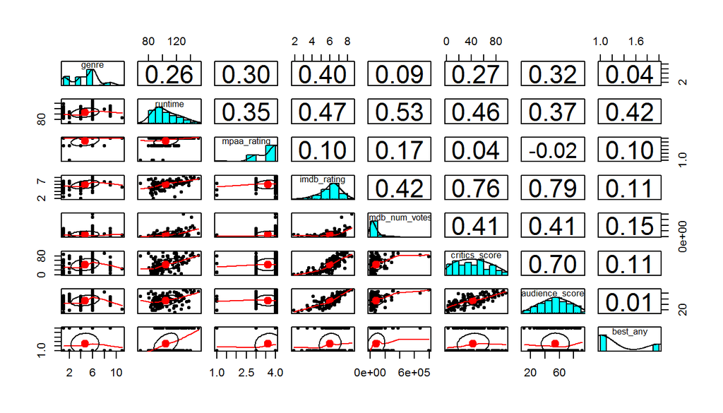

```r
#uses the psych package
pairs.panels(movies_filtered)
```

The matrix plot above allows us to visualize the relationship among all variables in one single image.

The oval-shaped object in the scatter plots above are called correlation ellipses. They provide a visualization of how strongly the correlated values are. The dot at the center of the ellipse indicates the point of the mean value for the x axis and y axis variables. The correlation between the two variables is indicated by the shape of the ellipse. An almost perfectly round oval indicates a very week correlation.

The curve drawn on the scatter plot is called a loess smooth. It indicates the general relationship between the x axis and y axis variables. Note the scatter plot between runtime and audience score. There appears there may be a slight nonlinear trend indicating there may be a higher audience score with short and longer movies with some in the center falling out of favor. This finding could not have been found from correlations alone.

Check for correlation among the variables. This step is very important to understand the relation of dependent variable with the independent variables and correlations among the variables. In general, there should not be any correlation among the independent variables. Other than `critics_score`, `imdb_rating` and `audience_score`, there do not appear to be any notably strong correlations.

## Part 4: Modeling

The project objective for this section:

*Develop a multiple linear regression model to predict a numerical variable in the dataset. The response variable and the explanatory variables can be existing variables in the dataset, or new variables you create based on existing variables.*

### Initial Model

To get started, we will build a linear model using all the remaining variables:

```r
MLR <- lm(audience_score ~., data=movies_filtered)
summary(MLR)
```

```
##
## Call:
## lm(formula = audience_score ~ ., data = movies_filtered)
##
## Residuals:
##     Min      1Q  Median      3Q     Max
## -31.953  -6.051   0.535   6.621  30.722
##
## Coefficients:
##                                  Estimate Std. Error t value Pr(>|t|)
## (Intercept)                    -1.203e+01  1.215e+01  -0.990  0.32444
## genreAnimation                  1.799e+01  6.855e+00   2.625  0.00999 **
## genreComedy                     4.449e+00  3.186e+00   1.396  0.16565
## genreDrama                      1.031e+01  3.149e+00   3.273  0.00145 **
## genreMusical & Performing Arts  2.379e+01  1.147e+01   2.074  0.04056 *
## genreMystery & Suspense        -9.910e-02  4.538e+00  -0.022  0.98262
## genreScience Fiction & Fantasy -1.703e+01  1.103e+01  -1.544  0.12568
## runtime                        -4.656e-02  8.696e-02  -0.535  0.59357
## mpaa_ratingPG                   7.127e+00  8.227e+00   0.866  0.38835
## mpaa_ratingPG-13                6.201e+00  8.630e+00   0.719  0.47401
## imdb_rating                     8.949e+00  1.420e+00   6.302 7.37e-09 ***
## imdb_num_votes                  2.407e-05  1.059e-05   2.274  0.02505 *
## critics_score                   9.251e-02  6.413e-02   1.443  0.15217
## best_anyYes                    -3.561e+00  2.398e+00  -1.485  0.14057
## ---
## Signif. codes:  0 '***' 0.001 '**' 0.01 '*' 0.05 '.' 0.1 ' ' 1
##
## Residual standard error: 10.64 on 103 degrees of freedom
## Multiple R-squared:  0.7332, Adjusted R-squared:  0.6995
## F-statistic: 21.77 on 13 and 103 DF,  p-value: < 2.2e-16
```

### Model Selection

We will now proceed with the variable selection : to select the best model answering our research question, we will perform a backward adjusted R<sup>2</sup> elimination.

We saw in the model summary above that genre - Mystery & Suspense has the highest p-value: 0.98262. Because `genre` is a factor variable, we must decide whether we remove all `genre` variables or keep them all. Since the `genreDrama` has a significant p-value, we will keep them all.

Conversely, both of the `mpaa_rating` variables have non-significant p-values. Therefore they are all candidates for removal. Let’s do that now:

```r
MLR1 <- lm(audience_score ~. -mpaa_rating, data=movies_filtered)
summary(MLR1)
```

```
##
## Call:
## lm(formula = audience_score ~ . - mpaa_rating, data = movies_filtered)
##
## Residuals:
##     Min      1Q  Median      3Q     Max
## -31.224  -6.292   1.163   6.328  30.939
##
## Coefficients:
##                                  Estimate Std. Error t value Pr(>|t|)
## (Intercept)                    -5.917e+00  9.734e+00  -0.608  0.54459
## genreAnimation                  1.435e+01  4.812e+00   2.981  0.00357 **
## genreComedy                     4.244e+00  3.111e+00   1.364  0.17535
## genreDrama                      9.960e+00  3.094e+00   3.219  0.00171 **
## genreMusical & Performing Arts  2.420e+01  1.127e+01   2.148  0.03405 *
## genreMystery & Suspense        -6.529e-01  4.365e+00  -0.150  0.88141
## genreScience Fiction & Fantasy -1.751e+01  1.088e+01  -1.610  0.11042
## runtime                        -5.287e-02  8.284e-02  -0.638  0.52469
## imdb_rating                     9.172e+00  1.377e+00   6.659 1.29e-09 ***
## imdb_num_votes                  2.375e-05  1.052e-05   2.259  0.02594 *
## critics_score                   9.086e-02  6.365e-02   1.428  0.15640
## best_anyYes                    -3.548e+00  2.384e+00  -1.489  0.13960
## ---
## Signif. codes:  0 '***' 0.001 '**' 0.01 '*' 0.05 '.' 0.1 ' ' 1
##
## Residual standard error: 10.58 on 105 degrees of freedom
## Multiple R-squared:  0.7309, Adjusted R-squared:  0.7027
## F-statistic: 25.93 on 11 and 105 DF,  p-value: < 2.2e-16
```

The results of the linear regression without the `mpaa_rating` variable is show in the first line of Step 1 in the table below. The adjusted R<sup>2</sup> value is 0.7027 - just a bit higher than the full model.

Continuing the process of removing one variable from the equation and recording the resultant adjusted R<sup>2</sup> value is continued. Note that I changed the [method to modify the regression model](http://www.r-bloggers.com/using-the-update-function-during-variable-selection/) starting in Step 2 to make it simpler.

(Could have automated this process using [this as a guide](http://www.r-bloggers.com/variable-selection-using-automatic-methods/) but performing this manually served as a better learning exercise.)

| Step | Variables Included | Removed | adjusted R^2 |
| --- | --- | --- | --- |
| Full | MLR <- lm(audience_score ~., movies_filtered) | – | 0.6995 |
| Step 1 | MLR1 <- lm(audience_score ~. -mpaa_rating, movies_filtered) | mpaa_rating | **0.7027** |
| – | MLR <- lm(audience_score ~. -runtime, movies_filtered) | runtime | 0.7016 |
| – | MLR <- lm(audience_score ~. -best_any, movies_filtered) | best_any | 0.6961 |
| – | MLR <- lm(audience_score ~. -genre, movies_filtered) | genre | 0.6532 |
| – | MLR <- lm(audience_score ~. -critics_score, movies_filtered) | critics_score | 0.6964 |
| – | MLR <- lm(audience_score ~. -imdb_rating, movies_filtered) | imdb_rating | 0.5877 |
| – | MLR <- lm(audience_score ~. -imdb_num_votes, movies_filtered) | imdb_num_votes | 0.6875 |
| Step 2 | MLR2 <- update(MLR1, .~. -runtime) | runtime | **0.7044** |
| – | MLR2 <- update(MLR1, .~. -imdb_rating) | imdb_rating | 0.5812 |
| – | MLR2 <- update(MLR1, .~. -imdb_num_votes) | imdb_num_votes | 0.6912 |
| – | MLR2 <- update(MLR1, .~. -critics_score) | critics_score | 0.6998 |
| – | MLR2 <- update(MLR1, .~. -best_any) | best_any | 0.6993 |
| Step 3 | MLR3 <- update(MLR2, .~. -imdb_rating) | imdb_rating | 0.5779 |
| – | MLR3 <- update(MLR2, .~. -imdb_num_votes) | imdb_num_votes | 0.6865 |
| – | MLR3 <- update(MLR2, .~. -critics_score) | critics_score | 0.6961 |
| – | MLR3 <- update(MLR2, .~. -best_any) | best_any | 0.6993 |

Using backwards selection using the adjusted R<sup>2</sup> method suggests that the model with an adjusted R<sup>2</sup> value of 0.7044 explains 70% of the variability in the response variable explained by the explanatory variables. This is the highest performing model. This will serve as the model for our predictions below.

#### Assumptions

Multiple linear regression has some inherent assumptions that we should evaluate:

1. Each variable is linearly related to the outcome
2. The residuals of the model are nearly normal
3. The variability of the residuals is nearly constant
4. The residuals are independent

Let’s evaluate each of these assumptions.

##### Linear relationships between Numerical x and y

We evaluate this assumption by looking at the linear relationship between each (numerical) explanatory variable and the response using scatter plots of y vs. each x, and residuals plots of residuals vs. each x. The scatter plots were provided in the pairs ploy above. The residual plots are provided below.

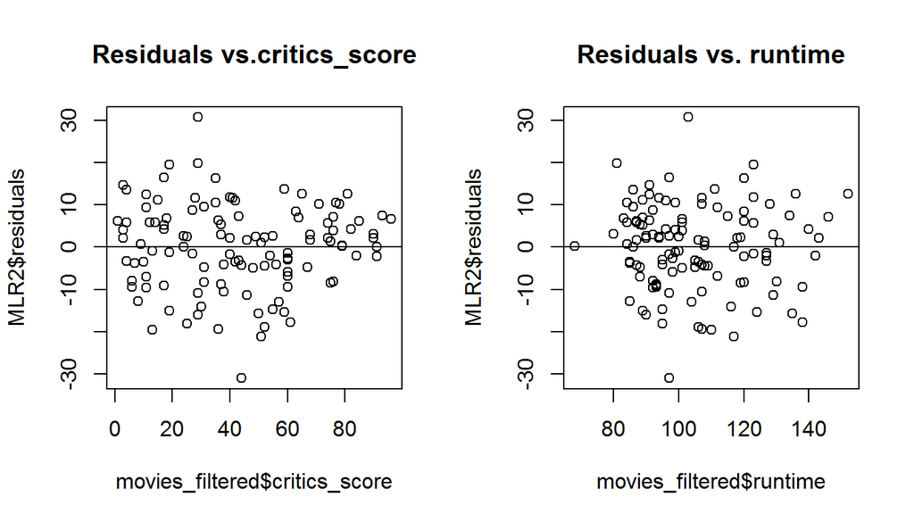

```r
MLR2 <- update(MLR1, .~. -runtime)
par(mfrow=c(1,2))
plot(MLR2$residuals ~ movies_filtered$critics_score, main = "Residuals vs.critics_score")
abline(h=0)
plot(MLR2$residuals ~ movies_filtered$runtime, main = "Residuals vs. runtime")
abline(h=0)
```

Because the residuals look reasonably normal around 0, we can assume this condition is satisfied.

##### Nearly Normal Residuals with Mean 0

A histogram of the residuals below appears nearly normal around 0. The normal probability plot below the histogram does not show any notable deviations from the mean. These factors support the assumption.

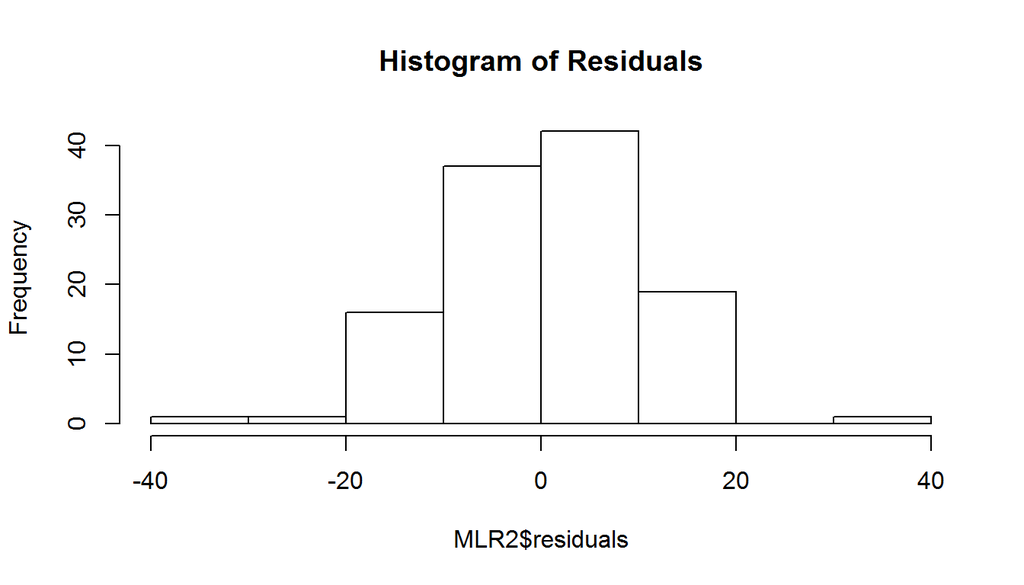

```r
hist(MLR2$residuals, main = "Histogram of Residuals")
```

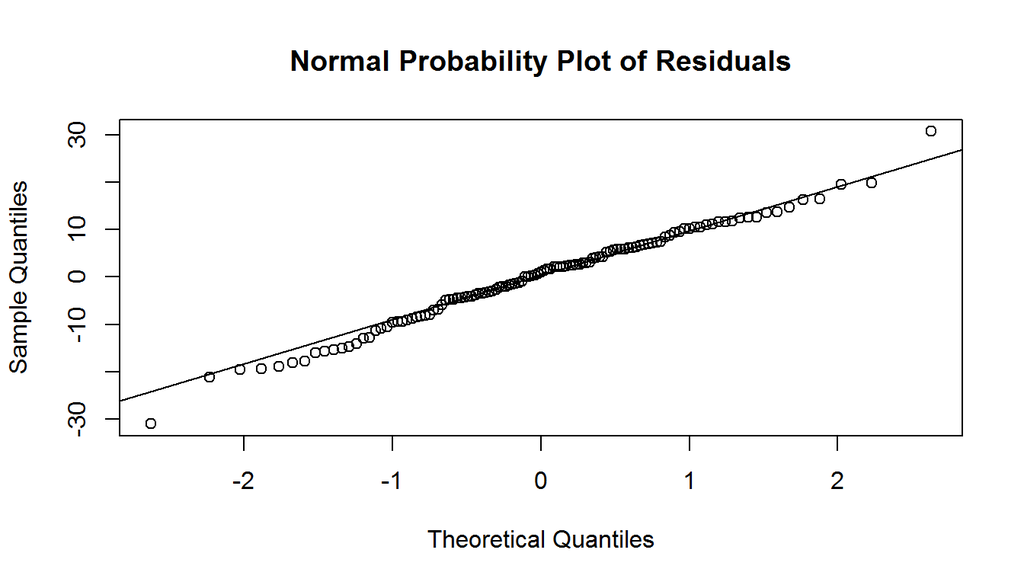

```r
qqnorm(MLR2$residuals, main = "Normal Probability Plot of Residuals")
qqline(MLR2$residuals)
```

##### Variablility of residuals is nearly constant

We evaluate homoscedasticity using the plots below:

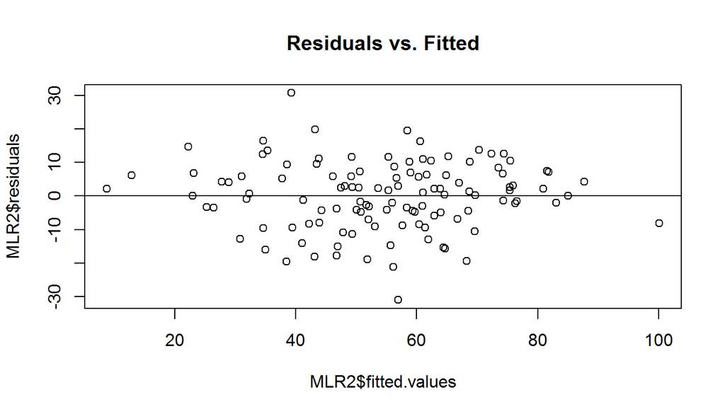

```r
plot(MLR2$residuals ~ MLR2$fitted.values, main = "Residuals vs. Fitted")
abline(h=0)
```

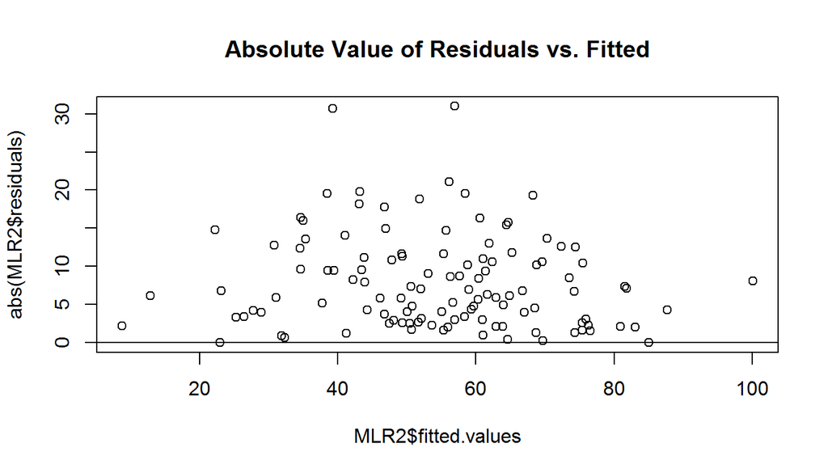

```r
plot(abs(MLR2$residuals) ~ MLR2$fitted.values, main = "Absolute Value of Residuals vs. Fitted")
abline(h=0)
```

We don’t see a fan shape here. It appears that the variability of the residual stays constant as the value of the fitted or the predicted values change, so, the constant variability condition appears to be met.

The absolute value of residuals plot can be thought of simply the first plot folded in half. So if we were to see a fan shape in the first plot, we would see a triangle in the absolute value of residuals versus fitted plot. Doesn’t exactly seem to be the case, so it seems like this condition is met as well.

##### Independent Residuals

Independent residuals basically means independent observations. If we have any time series structure, or if we’re suspecting that there may be any time series structure in our data set, we can check for independent residuals using the residuals versus the order of data collection plot. If that is not a consideration, to check to see, if the residuals are independent, we don’t really have another diagnostic approach, diagnostic graph that we can use. Instead, we want to go back to first principles and think about how the data are sampled. The sampling of the data to obtain independent observations was discussed in the beginning of this analysis and we reached the conclusion that the data is a random sample and is generalizable.

## Part 5: Prediction

The project objective for this section:

*Pick a movie from 2016 (a new movie that is not in the sample) and do a prediction for this movie using your the model you developed and the `predict` function in R. Also quantify the uncertainty around this prediction using an appropriate interval.*

The movie which audience score we will try to predict is *The Huntsman: Winter’s War*. Using data from IMDB and Rotten Tomatoes a dataframe is created:

```r
huntsman <- data.frame(genre = "Action & Adventure", imdb_rating = 6.1, imdb_num_votes = 31636, critics_score = 17, best_any = "Yes")
```

The `genre`, `imdb_num_votes` and `imdb_rating` variables come from the IMDb website and the *critics_score* variable and the response come from the Rotten Tomatoes website. We will now predict the audience score with our model.

Let’s use our regression model to predict the `audience_score`:

```r
MLR2 <- update(MLR1, .~. -runtime)
huntsman_score <- predict(MLR2, newdata = huntsman, interval = "prediction")
huntsman_score
```

```
##        fit      lwr      upr
## 1 43.09548 21.15615 65.03481
```

Let’s evaluate the output from the *The Huntsman: Winter’s War* prediction:

1. The predicted `audience_score` is 43.1.
2. The 95% confidence interval is 21.2 - 65.

Note: The actual `audience_score` for *The Huntsman: Winter’s War* is [48%](https://www.rottentomatoes.com/m/the_huntsman_winters_war/).

With this information we can conclude that we are 95% confident that the actual `audience_score` for *The Huntsman: Winter’s War* is between 21.2 - 65. The model returns an interval that includes our predicted value of 43.1 - very close to the actual score of 48!

## Part 6: Conclusion

The project objective for this section:

*A brief summary of your findings from the previous sections without repeating your statements from earlier as well as a discussion of what you have learned about the data and your research question. You should also discuss any shortcomings of your current study (either due to data collection or methodology) and include ideas for possible future research.*

We began this analysis with 32 variables that seemed to provide promise that we could build a robust model to predict the `audience_score` reliably. However, as the data was examined and the variables evaluated and modified to meet the needs of the research question, our final data set was limited to one response variable and 7 explanatory variables. Our model selection determined that the best performing model was the model with an adjusted R<sup>2</sup> value of ~70%.

The model provided accuracy to properly predict the value of a 2016 movie - the predicted value fell within the 95% confidence levels. We can explain only 70% of the variance of `audience_score`. I submit this is a relatively high performing linear regression predicative model model the relatively basic tools used to construct it. I am happy with the results.